```python
import pandas as pd
import numpy as np
import os
```

# Lecture 9 – Combining Data

## DSC 80, Spring 2022

### Announcements

- Discussion 3 is due (for extra credit!) **tomorrow at 11:59PM**.
- Lab 3 is due on **Monday, April 18th 11:59PM**.
  - Check [here](https://campuswire.com/c/G325FA25B/feed/507) for clarifications.
- Lab 1 (+more) grades are released – see [this post](https://campuswire.com/c/G325FA25B/feed/509) for details, and [this post](https://campuswire.com/c/G325FA25B/feed/508) for assignment solutions.
- Watch [this video 🎥](https://www.youtube.com/watch?v=uUawZfAgA64) for tips on how to work with the command-line.
- Project 2 will be released this weekend.

### Agenda

- Concatenating vertically.
- Concatenating horizontally.
- Joining and merging.
- Working with time series data.

Good resource: `pandas` [User Guide](https://pandas.pydata.org/docs/user_guide/merging.html).

## Recap: Concatenating vertically

### Example: Grades

By default, `pd.concat` stacks DataFrames row-wise, i.e. on top of one another.

```python
section_A = pd.DataFrame({
    'Name': ['Annie', 'Billy', 'Sally', 'Tommy'],
    'Midterm': [98, 82, 23, 45],
    'Final': [88, 100, 99, 67]
})

section_A
```

|  | Name | Midterm | Final |
| --- | --- | --- | --- |
| 0 | Annie | 98 | 88 |
| 1 | Billy | 82 | 100 |
| 2 | Sally | 23 | 99 |
| 3 | Tommy | 45 | 67 |

```python
section_B = pd.DataFrame({
    'Name': ['Junior', 'Rex', 'Flash'],
    'Midterm': [70, 99, 81],
    'Final': [42, 25, 90]
})

section_B
```

|  | Name | Midterm | Final |
| --- | --- | --- | --- |
| 0 | Junior | 70 | 42 |
| 1 | Rex | 99 | 25 |
| 2 | Flash | 81 | 90 |

Let's use `pd.concat` on a list of the above two DataFrames.

```python
pd.concat([section_A, section_B])
```

|  | Name | Midterm | Final |
| --- | --- | --- | --- |
| 0 | Annie | 98 | 88 |
| 1 | Billy | 82 | 100 |
| 2 | Sally | 23 | 99 |
| 3 | Tommy | 45 | 67 |
| 0 | Junior | 70 | 42 |
| 1 | Rex | 99 | 25 |
| 2 | Flash | 81 | 90 |

### ⚠️ Warning: No loops!

- `pd.concat` returns a copy; it does not modify any of the input DataFrames.
- Do **not** use `pd.concat` in a loop, as it has terrible time and space efficiency.

```
total = pd.DataFrame()
for df in dataframes:
    total = total.concat(df)
```

- Instead, use `pd.concat(dataframes)`, where `dataframes` is a list of DataFrames.

## Concatenating horizontally

### Example: Grades (again)

Suppose we have two DataFrames, `exams` and `assignments`, which both contain different attributes for the same individuals.

```python
exams = section_A.copy()
exams
```

|  | Name | Midterm | Final |
| --- | --- | --- | --- |
| 0 | Annie | 98 | 88 |
| 1 | Billy | 82 | 100 |
| 2 | Sally | 23 | 99 |
| 3 | Tommy | 45 | 67 |

```python
assignments = exams[['Name']].assign(Homeworks=[99, 45, 23, 81],
                                     Labs=[100, 100, 99, 100])

assignments
```

|  | Name | Homeworks | Labs |
| --- | --- | --- | --- |
| 0 | Annie | 99 | 100 |
| 1 | Billy | 45 | 100 |
| 2 | Sally | 23 | 99 |
| 3 | Tommy | 81 | 100 |

If we try to combine these DataFrames with `pd.concat`, we don't quite get what we're looking for.

```python
pd.concat([exams, assignments])
```

|  | Name | Midterm | Final | Homeworks | Labs |
| --- | --- | --- | --- | --- | --- |
| 0 | Annie | 98.0 | 88.0 | NaN | NaN |
| 1 | Billy | 82.0 | 100.0 | NaN | NaN |
| 2 | Sally | 23.0 | 99.0 | NaN | NaN |
| 3 | Tommy | 45.0 | 67.0 | NaN | NaN |
| 0 | Annie | NaN | NaN | 99.0 | 100.0 |
| 1 | Billy | NaN | NaN | 45.0 | 100.0 |
| 2 | Sally | NaN | NaN | 23.0 | 99.0 |
| 3 | Tommy | NaN | NaN | 81.0 | 100.0 |

But that's where the `axis` argument becomes handy.

Remember, most `pandas` operations default to `axis=0`, but here we want to concatenate the columns of `exams` to the columns of `assignments`, so we should use `axis=1`.

```python
pd.concat([exams, assignments], axis=1)
```

|  | Name | Midterm | Final | Name | Homeworks | Labs |
| --- | --- | --- | --- | --- | --- | --- |
| 0 | Annie | 98 | 88 | Annie | 99 | 100 |
| 1 | Billy | 82 | 100 | Billy | 45 | 100 |
| 2 | Sally | 23 | 99 | Sally | 23 | 99 |
| 3 | Tommy | 45 | 67 | Tommy | 81 | 100 |

Note that the `'Name'` column appears twice!

### Concatenating horizontally

- To concatenate two DataFrames horizontally, use `pd.concat` with `axis=1`.
- Concatenation is done by matching indexes, regardless of their order. **It does not look at any column values!**

[figure not shown]

Note that the call to `pd.concat` below works as expected, even though the orders of the names in `exams_by_name` and `assignments_by_name` are different.

```python
# .loc[::-1] reverses the rows of the DataFrame
exams_by_name = exams.set_index('Name').loc[::-1]
exams_by_name
```

| Name | Midterm | Final |
| --- | --- | --- |
| Tommy | 45 | 67 |
| Sally | 23 | 99 |
| Billy | 82 | 100 |
| Annie | 98 | 88 |

```python
assignments_by_name = assignments.set_index('Name')
assignments_by_name
```

| Name | Homeworks | Labs |
| --- | --- | --- |
| Annie | 99 | 100 |
| Billy | 45 | 100 |
| Sally | 23 | 99 |
| Tommy | 81 | 100 |

```python
pd.concat([exams_by_name, assignments_by_name], axis=1)
```

| Name | Midterm | Final | Homeworks | Labs |
| --- | --- | --- | --- | --- |
| Tommy | 45 | 67 | 81 | 100 |
| Sally | 23 | 99 | 23 | 99 |
| Billy | 82 | 100 | 45 | 100 |
| Annie | 98 | 88 | 99 | 100 |

Remember that `pd.concat` only looks at the index when combining rows, not at any other columns.

```python
exams_reversed = exams.loc[::-1].reset_index(drop=True)
exams_reversed
```

|  | Name | Midterm | Final |
| --- | --- | --- | --- |
| 0 | Tommy | 45 | 67 |
| 1 | Sally | 23 | 99 |
| 2 | Billy | 82 | 100 |
| 3 | Annie | 98 | 88 |

```python
assignments
```

|  | Name | Homeworks | Labs |
| --- | --- | --- | --- |
| 0 | Annie | 99 | 100 |
| 1 | Billy | 45 | 100 |
| 2 | Sally | 23 | 99 |
| 3 | Tommy | 81 | 100 |

```python
pd.concat([exams_reversed, assignments], axis=1)
```

|  | Name | Midterm | Final | Name | Homeworks | Labs |
| --- | --- | --- | --- | --- | --- | --- |
| 0 | Tommy | 45 | 67 | Annie | 99 | 100 |
| 1 | Sally | 23 | 99 | Billy | 45 | 100 |
| 2 | Billy | 82 | 100 | Sally | 23 | 99 |
| 3 | Annie | 98 | 88 | Tommy | 81 | 100 |

### Missing rows?

If we concatenate two DataFrames that don't share row indexes, `NaN`s are added in the rows that aren't shared.

```python
exams_extra = exams.copy()
exams_extra.loc[4] = ['Junior', 100, 100]
exams_extra
```

|  | Name | Midterm | Final |
| --- | --- | --- | --- |
| 0 | Annie | 98 | 88 |
| 1 | Billy | 82 | 100 |
| 2 | Sally | 23 | 99 |
| 3 | Tommy | 45 | 67 |
| 4 | Junior | 100 | 100 |

```python
assignments
```

|  | Name | Homeworks | Labs |
| --- | --- | --- | --- |
| 0 | Annie | 99 | 100 |
| 1 | Billy | 45 | 100 |
| 2 | Sally | 23 | 99 |
| 3 | Tommy | 81 | 100 |

```python
pd.concat([exams_extra, assignments], axis=1)
```

|  | Name | Midterm | Final | Name | Homeworks | Labs |
| --- | --- | --- | --- | --- | --- | --- |
| 0 | Annie | 98 | 88 | Annie | 99.0 | 100.0 |
| 1 | Billy | 82 | 100 | Billy | 45.0 | 100.0 |
| 2 | Sally | 23 | 99 | Sally | 23.0 | 99.0 |
| 3 | Tommy | 45 | 67 | Tommy | 81.0 | 100.0 |
| 4 | Junior | 100 | 100 | NaN | NaN | NaN |

### Summary: `pd.concat`

- `pd.concat` "stitches" two or more DataFrames together.
- If you use `axis=0`, the DataFrames are concatenated **vertically** based on column names (rows on top of rows).
- If you use `axis=1`, the DataFrames are concatenated **horizontally** based on row indexes (columns next to columns).

## Joining and merging

### Concatenating horizontally

- `pd.concat` with `axis=1` combines DataFrames horizontally.
- To combine DataFrames horizontally in more advanced ways, we perform a **join** (also known as a **merge**).

### Joins

- A **join** creates a new DataFrame by combining the rows of two DataFrames.
- A join is appropriate when we have two sources of information
  - about the same individuals, that is
  - linked by a common column.
- The common column is called the **join key**.

### Example

Here, the join key is `'Player Id'`.

[figure not shown]

### The `merge` method

- The `merge` DataFrame method joins two tables by columns or indexes.
  - "Merge" is just `pandas`' word for "join".
  - It also exists as a `pandas` function.
- If join keys are not specified, all shared columns between the two DataFrames are used by default.

Let's work with a small example.

```python
temps = pd.DataFrame({
    'City': ['San Diego', 'Toronto', 'Rome'],
    'Temperature': [76, 28, 56]
})

temps
```

|  | City | Temperature |
| --- | --- | --- |
| 0 | San Diego | 76 |
| 1 | Toronto | 28 |
| 2 | Rome | 56 |

```python
countries = pd.DataFrame({
    'City': ['Toronto', 'Shanghai', 'San Diego'],
    'Country': ['Canada', 'China', 'USA']
})

countries
```

|  | City | Country |
| --- | --- | --- |
| 0 | Toronto | Canada |
| 1 | Shanghai | China |
| 2 | San Diego | USA |

```python
temps.merge(countries)
```

|  | City | Temperature | Country |
| --- | --- | --- | --- |
| 0 | San Diego | 76 | USA |
| 1 | Toronto | 28 | Canada |

We didn't specify which columns to merge on, so it defaulted to `'City'`.

### Join types: inner joins

- Note that `'Rome'` and `'Shanghai'` do not appear in the merged DataFrame.
- This is because there is:
  - no city named `'Rome'` in the second DataFrame, and
  - no city named `'Shanghai'` in the first DataFrame.
- The default type of join that `merge` performs is an **inner join**, which keeps the **intersection** of the join keys.

[figure not shown]

### Different join types handle mismatches differently

There are four types of joins.

- **Inner:** keep **only** matching keys (intersection).
- **Outer:** keeps **all** keys in both DataFrames (union).
- **Left:** keep all keys in the left DataFrame, whether or not they are in the right DataFrame.
- **Right:** keep all keys in the right DataFrame, whether or not they are in the left DataFrame.

[figure not shown]

### Examples of join types

- To specify which type of join we want to perform, we use the `how` argument (the default is `how='inner'`).
- The left DataFrame is the DataFrame that **preceeds** `.merge`, and the right DataFrame is the argument to `merge`.
- Alternatively, you can use the `pd.merge` **function**, in which the first argument is the left DataFrame and the second argument is the right DataFrame.

```python
temps
```

|  | City | Temperature |
| --- | --- | --- |
| 0 | San Diego | 76 |
| 1 | Toronto | 28 |
| 2 | Rome | 56 |

```python
countries
```

|  | City | Country |
| --- | --- | --- |
| 0 | Toronto | Canada |
| 1 | Shanghai | China |
| 2 | San Diego | USA |

Let's try an outer join.

```python
temps.merge(countries, how='outer')
```

|  | City | Temperature | Country |
| --- | --- | --- | --- |
| 0 | San Diego | 76.0 | USA |
| 1 | Toronto | 28.0 | Canada |
| 2 | Rome | 56.0 | NaN |
| 3 | Shanghai | NaN | China |

```python
# merge is also a pandas function
pd.merge(temps, countries, how='outer')
```

|  | City | Temperature | Country |
| --- | --- | --- | --- |
| 0 | San Diego | 76.0 | USA |
| 1 | Toronto | 28.0 | Canada |
| 2 | Rome | 56.0 | NaN |
| 3 | Shanghai | NaN | China |

Note the `NaN`s in the rows for `'Rome'` and `'Shanghai'`.

Also note that an outer join is what `pd.concat` does by default, when there are no duplicated keys in either DataFrame.

```python
pd.concat([temps.set_index('City'), countries.set_index('City')], axis=1)
```

| City | Temperature | Country |
| --- | --- | --- |
| San Diego | 76.0 | USA |
| Toronto | 28.0 | Canada |
| Rome | 56.0 | NaN |
| Shanghai | NaN | China |

Let's try left and right joins.

```python
temps
```

|  | City | Temperature |
| --- | --- | --- |
| 0 | San Diego | 76 |
| 1 | Toronto | 28 |
| 2 | Rome | 56 |

```python
countries
```

|  | City | Country |
| --- | --- | --- |
| 0 | Toronto | Canada |
| 1 | Shanghai | China |
| 2 | San Diego | USA |

First, a left join.

```python
temps.merge(countries, how='left')
```

|  | City | Temperature | Country |
| --- | --- | --- | --- |
| 0 | San Diego | 76 | USA |
| 1 | Toronto | 28 | Canada |
| 2 | Rome | 56 | NaN |

How about a right join?

```python
temps.merge(countries, how='right')
```

|  | City | Temperature | Country |
| --- | --- | --- | --- |
| 0 | Toronto | 28.0 | Canada |
| 1 | Shanghai | NaN | China |
| 2 | San Diego | 76.0 | USA |

Note that `a.merge(b, how='left')` is the same as `b.merge(a, how='right')`. The only difference is the order of the columns in the result.

```python
countries.merge(temps, how='left')
```

|  | City | Country | Temperature |
| --- | --- | --- | --- |
| 0 | Toronto | Canada | 28.0 |
| 1 | Shanghai | China | NaN |
| 2 | San Diego | USA | 76.0 |

### Specifying join keys

- `pandas` defaults to using the shared column(s) as join keys.
- If there are multiple shared column names and you only want to join on one of them, **or** if there are no shared column names, then you will need to specify which columns to join on.
- Two solutions:
  1. Use the `on` argument if the desired column(s) have the same names in both DataFrames.
  2. Use the `left_on` or `left_index` argument AND the `right_on` or `right_index` argument.

```python
exams
```

|  | Name | Midterm | Final |
| --- | --- | --- | --- |
| 0 | Annie | 98 | 88 |
| 1 | Billy | 82 | 100 |
| 2 | Sally | 23 | 99 |
| 3 | Tommy | 45 | 67 |

```python
overall = pd.DataFrame({
    'PID': ['A15253545', 'A10348245', 'A13349069', 'A18485824', 'A10094857'],
    'Student': ['Billy', 'Sally', 'Annie', 'Larry', 'Johnny'],
    'Final': [88, 64, 91, 45, 89]
})

overall
```

|  | PID | Student | Final |
| --- | --- | --- | --- |
| 0 | A15253545 | Billy | 88 |
| 1 | A10348245 | Sally | 64 |
| 2 | A13349069 | Annie | 91 |
| 3 | A18485824 | Larry | 45 |
| 4 | A10094857 | Johnny | 89 |

This is not what we're looking for.

```python
exams.merge(overall)
```

|  | Name | Midterm | Final | PID | Student |
| --- | --- | --- | --- | --- | --- |
| 0 | Annie | 98 | 88 | A15253545 | Billy |

Instead, we need to tell `pandas` to look in the `'Name'` column of `exams` and `'Student'` column of `overall`.

```python
exams.merge(overall, left_on='Name', right_on='Student')
```

|  | Name | Midterm | Final_x | PID | Student | Final_y |
| --- | --- | --- | --- | --- | --- | --- |
| 0 | Annie | 98 | 88 | A13349069 | Annie | 91 |
| 1 | Billy | 82 | 100 | A15253545 | Billy | 88 |
| 2 | Sally | 23 | 99 | A10348245 | Sally | 64 |

If there are shared column names in the two DataFrames you are merging **that you are not using as join keys**, by default `'_x'` and `'_y'` are appended to their names.

```python
exams.merge(overall, left_on='Name', right_on='Student', suffixes=('_Exam', '_Overall'))
```

|  | Name | Midterm | Final_Exam | PID | Student | Final_Overall |
| --- | --- | --- | --- | --- | --- | --- |
| 0 | Annie | 98 | 88 | A13349069 | Annie | 91 |
| 1 | Billy | 82 | 100 | A15253545 | Billy | 88 |
| 2 | Sally | 23 | 99 | A10348245 | Sally | 64 |

If the desired join key is in the index, assign `left_index` or `right_index` to `True`.

```python
exams
```

|  | Name | Midterm | Final |
| --- | --- | --- | --- |
| 0 | Annie | 98 | 88 |
| 1 | Billy | 82 | 100 |
| 2 | Sally | 23 | 99 |
| 3 | Tommy | 45 | 67 |

```python
overall_by_student = overall.set_index('Student')
overall_by_student
```

| Student | PID | Final |
| --- | --- | --- |
| Billy | A15253545 | 88 |
| Sally | A10348245 | 64 |
| Annie | A13349069 | 91 |
| Larry | A18485824 | 45 |
| Johnny | A10094857 | 89 |

```python
exams.merge(overall_by_student, left_on='Name', right_index=True, suffixes=('_Exam', '_Overall'))
```

|  | Name | Midterm | Final_Exam | PID | Final_Overall |
| --- | --- | --- | --- | --- | --- |
| 0 | Annie | 98 | 88 | A13349069 | 91 |
| 1 | Billy | 82 | 100 | A15253545 | 88 |
| 2 | Sally | 23 | 99 | A10348245 | 64 |

## Many-to-one & many-to-many joins

### One-to-one joins

- So far in this lecture, the joins we have worked with are called **one-to-one** joins.
- Neither the left DataFrame nor the right DataFrame contained any duplicates in the join key.
- What if there are duplicated join keys, in one or both of the DataFrames we are merging?

### Many-to-one joins

- Many-to-one joins are joins where **one** of the DataFrames contains duplicate values in the join key.
- The resulting DataFrame will preserve those duplicate entries as appropriate.

```python
profs = pd.DataFrame(
[['Brad', 'UCB', 8],
 ['Janine', 'UCSD', 7],
 ['Marina', 'UIC', 6],
 ['Justin', 'OSU', 4],
 ['Aaron', 'UCB', 4],
 ['Soohyun', 'UCSD', 1],
 ['Suraj', 'UCB', 1]],
    columns=['Name', 'School', 'Years']
)

profs
```

|  | Name | School | Years |
| --- | --- | --- | --- |
| 0 | Brad | UCB | 8 |
| 1 | Janine | UCSD | 7 |
| 2 | Marina | UIC | 6 |
| 3 | Justin | OSU | 4 |
| 4 | Aaron | UCB | 4 |
| 5 | Soohyun | UCSD | 1 |
| 6 | Suraj | UCB | 1 |

```python
schools = pd.DataFrame({
    'Abr': ['UCSD', 'UCLA', 'UCB', 'UIC'],
    'Full': ['University of California, San Diego', 'University of California, Los Angeles', 'University of California, Berkeley', 'University of Illinois Chicago']
})

schools
```

|  | Abr | Full |
| --- | --- | --- |
| 0 | UCSD | University of California, San Diego |
| 1 | UCLA | University of California, Los Angeles |
| 2 | UCB | University of California, Berkeley |
| 3 | UIC | University of Illinois Chicago |

Note that when merging `profs` and `schools`, the information from `schools` is duplicated (`'University of California, San Diego'` appears twice and `'University of California, Berkeley'` appears three times).

```python
profs.merge(schools, left_on='School', right_on='Abr', how='left')
```

|  | Name | School | Years | Abr | Full |
| --- | --- | --- | --- | --- | --- |
| 0 | Brad | UCB | 8 | UCB | University of California, Berkeley |
| 1 | Janine | UCSD | 7 | UCSD | University of California, San Diego |
| 2 | Marina | UIC | 6 | UIC | University of Illinois Chicago |
| 3 | Justin | OSU | 4 | NaN | NaN |
| 4 | Aaron | UCB | 4 | UCB | University of California, Berkeley |
| 5 | Soohyun | UCSD | 1 | UCSD | University of California, San Diego |
| 6 | Suraj | UCB | 1 | UCB | University of California, Berkeley |

### Many-to-many joins

Many-to-many joins are joins where both DataFrames have duplicate values in the join key.

```python
profs
```

|  | Name | School | Years |
| --- | --- | --- | --- |
| 0 | Brad | UCB | 8 |
| 1 | Janine | UCSD | 7 |
| 2 | Marina | UIC | 6 |
| 3 | Justin | OSU | 4 |
| 4 | Aaron | UCB | 4 |
| 5 | Soohyun | UCSD | 1 |
| 6 | Suraj | UCB | 1 |

```python
programs = pd.DataFrame({
    'uni': ['UCSD', 'UCSD', 'UCSD', 'UCB', 'OSU', 'OSU'],
    'dept': ['Math', 'HDSI', 'COGS', 'CS', 'Math', 'CS'],
    'grad_students': [205, 54, 281, 439, 304, 193]
})

programs
```

|  | uni | dept | grad_students |
| --- | --- | --- | --- |
| 0 | UCSD | Math | 205 |
| 1 | UCSD | HDSI | 54 |
| 2 | UCSD | COGS | 281 |
| 3 | UCB | CS | 439 |
| 4 | OSU | Math | 304 |
| 5 | OSU | CS | 193 |

Before running the following cell, try predicting the number of rows in the output.

```python
profs.merge(programs, left_on='School', right_on='uni')
```

|  | Name | School | Years | uni | dept | grad_students |
| --- | --- | --- | --- | --- | --- | --- |
| 0 | Brad | UCB | 8 | UCB | CS | 439 |
| 1 | Aaron | UCB | 4 | UCB | CS | 439 |
| 2 | Suraj | UCB | 1 | UCB | CS | 439 |
| 3 | Janine | UCSD | 7 | UCSD | Math | 205 |
| 4 | Janine | UCSD | 7 | UCSD | HDSI | 54 |
| 5 | Janine | UCSD | 7 | UCSD | COGS | 281 |
| 6 | Soohyun | UCSD | 1 | UCSD | Math | 205 |
| 7 | Soohyun | UCSD | 1 | UCSD | HDSI | 54 |
| 8 | Soohyun | UCSD | 1 | UCSD | COGS | 281 |
| 9 | Justin | OSU | 4 | OSU | Math | 304 |
| 10 | Justin | OSU | 4 | OSU | CS | 193 |

- `merge` stitched together every UCSD row in `profs` with every UCSD row in `programs`.
- Since there were 2 UCSD rows in `profs` and 3 in `programs`, there are $2 \cdot 3 = 6$ UCSD rows in the output. The same applies for all other schools.

## Example: SDPD vehicle stops

### Aside: accessing file names programmatically

- At times, you'll need to load in all of the files in a given folder.
- `os.listdir(dirname)` returns a **list** of the names of the files in the folder `dirname`.

```python
os.listdir('data')
```

```
['orders.csv',
 '.DS_Store',
 'stops_2017.csv',
 'military.csv',
 'stops_2016.csv',
 'race_codes.csv']
```

- Sometimes, you'll want to extract file names that follow a specific pattern. The `pathlib` library allows you to do this.

```python
import pathlib
file_list = list(pathlib.Path().glob('data/stops*.csv')) # glob allows for pattern matching
file_list
```

```
[PosixPath('data/stops_2017.csv'), PosixPath('data/stops_2016.csv')]
```

- You can accomplish something similar in the command-line.
- Place a `!` in front of a command in a Jupyter Notebook cell to run it on the command-line.

```python
!ls data/stops*.csv
```

```
data/stops_2016.csv data/stops_2017.csv
```

### Loading in the data

```python
file_list
```

```
[PosixPath('data/stops_2017.csv'), PosixPath('data/stops_2016.csv')]
```

```python
list_of_dfs = [pd.read_csv(file) for file in file_list]
```

```python
for df in list_of_dfs:
    display(df.head())
```

|  | stop_id | stop_cause | service_area | subject_race | subject_sex | subject_age | timestamp | stop_date | stop_time | sd_resident | arrested | searched | obtained_consent | contraband_found | property_seized |
| --- | --- | --- | --- | --- | --- | --- | --- | --- | --- | --- | --- | --- | --- | --- | --- |
| 0 | 1444799 | Moving Violation | 120 | I | M | 37 | 2017-01-01 00:03:00 | 2017-01-01 | 00:03:00 | N | N | N | NaN | NaN | NaN |
| 1 | 1444821 | Equipment Violation | 520 | W | M | 22 | 2017-01-01 00:25:00 | 2017-01-01 | 00:25:00 | N | N | N | NaN | NaN | NaN |
| 2 | 1447102 | Moving Violation | 520 | W | M | 29 | 2017-01-01 01:45:00 | 2017-01-01 | 01:45:00 | N | N | N | NaN | NaN | NaN |
| 3 | 1444801 | Equipment Violation | 720 | H | F | 61 | 2017-01-01 03:10:00 | 2017-01-01 | 03:10:00 | N | N | N | NaN | NaN | NaN |
| 4 | 1444802 | Equipment Violation | 120 | H | M | 24 | 2017-01-01 03:30:00 | 2017-01-01 | 03:30:00 | Y | N | N | NaN | NaN | NaN |

|  | stop_id | stop_cause | service_area | subject_race | subject_sex | subject_age | timestamp | stop_date | stop_time | sd_resident | arrested | searched | obtained_consent | contraband_found | property_seized |
| --- | --- | --- | --- | --- | --- | --- | --- | --- | --- | --- | --- | --- | --- | --- | --- |
| 0 | 1308198 | Equipment Violation | 530 | W | M | 28 | 2016-01-01 00:06:00 | 2016-01-01 | 0:06 | Y | N | N | N | N | N |
| 1 | 1308172 | Moving Violation | 520 | B | M | 25 | 2016-01-01 00:10:00 | 2016-01-01 | 0:10 | N | N | N | NaN | NaN | NaN |
| 2 | 1308171 | Moving Violation | 110 | H | F | 31 | 2016-01-01 00:14:00 | 2016-01-01 | 0:14 | NaN | NaN | NaN | NaN | NaN | NaN |
| 3 | 1308170 | Moving Violation | Unknown | W | F | 29 | 2016-01-01 00:16:00 | 2016-01-01 | 0:16 | N | N | N | NaN | NaN | NaN |
| 4 | 1308197 | Moving Violation | 230 | W | M | 52 | 2016-01-01 00:30:00 | 2016-01-01 | 0:30 | N | N | N | NaN | NaN | NaN |

We need to concatenate these two DataFrames **vertically**.

```python
stops = pd.concat(list_of_dfs, ignore_index=True)
```

```python
stops.head()
```

|  | stop_id | stop_cause | service_area | subject_race | subject_sex | subject_age | timestamp | stop_date | stop_time | sd_resident | arrested | searched | obtained_consent | contraband_found | property_seized |
| --- | --- | --- | --- | --- | --- | --- | --- | --- | --- | --- | --- | --- | --- | --- | --- |
| 0 | 1444799 | Moving Violation | 120 | I | M | 37 | 2017-01-01 00:03:00 | 2017-01-01 | 00:03:00 | N | N | N | NaN | NaN | NaN |
| 1 | 1444821 | Equipment Violation | 520 | W | M | 22 | 2017-01-01 00:25:00 | 2017-01-01 | 00:25:00 | N | N | N | NaN | NaN | NaN |
| 2 | 1447102 | Moving Violation | 520 | W | M | 29 | 2017-01-01 01:45:00 | 2017-01-01 | 01:45:00 | N | N | N | NaN | NaN | NaN |
| 3 | 1444801 | Equipment Violation | 720 | H | F | 61 | 2017-01-01 03:10:00 | 2017-01-01 | 03:10:00 | N | N | N | NaN | NaN | NaN |
| 4 | 1444802 | Equipment Violation | 120 | H | M | 24 | 2017-01-01 03:30:00 | 2017-01-01 | 03:30:00 | Y | N | N | NaN | NaN | NaN |

```python
len(stops)
```

```
206413
```

### Investigating races

Right now, `'subject_race'` is stored as a single character. What does `'I'` mean? `'H'`?

```python
stops.head()
```

|  | stop_id | stop_cause | service_area | subject_race | subject_sex | subject_age | timestamp | stop_date | stop_time | sd_resident | arrested | searched | obtained_consent | contraband_found | property_seized |
| --- | --- | --- | --- | --- | --- | --- | --- | --- | --- | --- | --- | --- | --- | --- | --- |
| 0 | 1444799 | Moving Violation | 120 | I | M | 37 | 2017-01-01 00:03:00 | 2017-01-01 | 00:03:00 | N | N | N | NaN | NaN | NaN |
| 1 | 1444821 | Equipment Violation | 520 | W | M | 22 | 2017-01-01 00:25:00 | 2017-01-01 | 00:25:00 | N | N | N | NaN | NaN | NaN |
| 2 | 1447102 | Moving Violation | 520 | W | M | 29 | 2017-01-01 01:45:00 | 2017-01-01 | 01:45:00 | N | N | N | NaN | NaN | NaN |
| 3 | 1444801 | Equipment Violation | 720 | H | F | 61 | 2017-01-01 03:10:00 | 2017-01-01 | 03:10:00 | N | N | N | NaN | NaN | NaN |
| 4 | 1444802 | Equipment Violation | 120 | H | M | 24 | 2017-01-01 03:30:00 | 2017-01-01 | 03:30:00 | Y | N | N | NaN | NaN | NaN |

```python
stops['subject_race'].value_counts(normalize=True)
```

```
W    0.411358
H    0.309249
B    0.112620
O    0.086896
A    0.046397
F    0.011923
V    0.005768
C    0.004899
I    0.004123
X    0.001446
K    0.001222
P    0.000990
J    0.000912
Z    0.000558
D    0.000543
L    0.000461
S    0.000349
G    0.000189
U    0.000097
Name: subject_race, dtype: float64
```

Fortunately, we have access to another dataset that describes each of the race codes.

```python
races = pd.read_csv('data/race_codes.csv')
races
```

|  | Race Code | Description |
| --- | --- | --- |
| 0 | A | OTHER ASIAN |
| 1 | B | BLACK |
| 2 | C | CHINESE |
| 3 | D | CAMBODIAN |
| 4 | F | FILIPINO |
| 5 | G | GUAMANIAN |
| 6 | H | HISPANIC |
| 7 | I | INDIAN |
| 8 | J | JAPANESE |
| 9 | K | KOREAN |
| 10 | L | LAOTIAN |
| 11 | O | OTHER |
| 12 | P | PACIFIC ISLANDER |
| 13 | S | SAMOAN |
| 14 | U | HAWAIIAN |
| 15 | V | VIETNAMESE |
| 16 | W | WHITE |
| 17 | Z | ASIAN INDIAN |

Let's join the distribution of races with the DataFrame of race codes.

**Question:** Is this a one-to-one join?

```python
race_percentages = stops['subject_race'].value_counts(normalize=True).rename('Proportion').to_frame()
race_percentages.merge(races, left_index=True, right_on='Race Code')
```

|  | Proportion | Race Code | Description |
| --- | --- | --- | --- |
| 16 | 0.411358 | W | WHITE |
| 6 | 0.309249 | H | HISPANIC |
| 1 | 0.112620 | B | BLACK |
| 11 | 0.086896 | O | OTHER |
| 0 | 0.046397 | A | OTHER ASIAN |
| 4 | 0.011923 | F | FILIPINO |
| 15 | 0.005768 | V | VIETNAMESE |
| 2 | 0.004899 | C | CHINESE |
| 7 | 0.004123 | I | INDIAN |
| 9 | 0.001222 | K | KOREAN |
| 12 | 0.000990 | P | PACIFIC ISLANDER |
| 8 | 0.000912 | J | JAPANESE |
| 17 | 0.000558 | Z | ASIAN INDIAN |
| 3 | 0.000543 | D | CAMBODIAN |
| 10 | 0.000461 | L | LAOTIAN |
| 13 | 0.000349 | S | SAMOAN |
| 5 | 0.000189 | G | GUAMANIAN |
| 14 | 0.000097 | U | HAWAIIAN |

The **level of granularity** of the races in our data right now seems inconsistent. For instance, `'WHITE'` and `'BLACK'` are much more broad than `'FILIPINO'`, `'JAPANESE'`, and `'GUAMANIAN'`.

### Adjusting granularity

Let's try and adjust our race data so that we have a consistent level of granularity. Here's what we want to create:

|  | Race Code | Description | Race_Category |
| --- | --- | --- | --- |
| 0 | A | OTHER ASIAN | Asian |
| 1 | B | BLACK | Black |
| 2 | C | CHINESE | Asian |
| 3 | D | CAMBODIAN | Asian |
| 4 | F | FILIPINO | Asian |

We can do this by manually defining a mapping between race codes and desired categories.

```python
race_dict = {'A':'Asian',
             'B':'Black',
             'C':'Asian',
             'D':'Asian',
             'F':'Asian',
             'G':'Asian',
             'H':'Hispanic',
             'I':'Native American',
             'J':'Asian',
             'K':'Asian',
             'L':'Asian',
             'O':'Other',
             'P':'Asian',
             'S':'Asian',
             'U':'Hawaiian',
             'V':'Asian',
             'W':'White',
             'Z':'Asian'
            }
```

There are two ways to replace all of the `'Race Code'`s in `races` with the above categories:

- Use the Series `replace` method.
- Convert the above mapping to a DataFrame and join it with `races`.

Joining requires sorting, where as replacing does not. Let's go with the first option.

```python
races['Race_Category'] = races['Race Code'].replace(race_dict)
races
```

|  | Race Code | Description | Race_Category |
| --- | --- | --- | --- |
| 0 | A | OTHER ASIAN | Asian |
| 1 | B | BLACK | Black |
| 2 | C | CHINESE | Asian |
| 3 | D | CAMBODIAN | Asian |
| 4 | F | FILIPINO | Asian |
| 5 | G | GUAMANIAN | Asian |
| 6 | H | HISPANIC | Hispanic |
| 7 | I | INDIAN | Native American |
| 8 | J | JAPANESE | Asian |
| 9 | K | KOREAN | Asian |
| 10 | L | LAOTIAN | Asian |
| 11 | O | OTHER | Other |
| 12 | P | PACIFIC ISLANDER | Asian |
| 13 | S | SAMOAN | Asian |
| 14 | U | HAWAIIAN | Hawaiian |
| 15 | V | VIETNAMESE | Asian |
| 16 | W | WHITE | White |
| 17 | Z | ASIAN INDIAN | Asian |

Now, we need to join `stops` with `races`. An important question is, what type of join should we use (inner, outer, left, right)?

```python
stops.head()
```

|  | stop_id | stop_cause | service_area | subject_race | subject_sex | subject_age | timestamp | stop_date | stop_time | sd_resident | arrested | searched | obtained_consent | contraband_found | property_seized |
| --- | --- | --- | --- | --- | --- | --- | --- | --- | --- | --- | --- | --- | --- | --- | --- |
| 0 | 1444799 | Moving Violation | 120 | I | M | 37 | 2017-01-01 00:03:00 | 2017-01-01 | 00:03:00 | N | N | N | NaN | NaN | NaN |
| 1 | 1444821 | Equipment Violation | 520 | W | M | 22 | 2017-01-01 00:25:00 | 2017-01-01 | 00:25:00 | N | N | N | NaN | NaN | NaN |
| 2 | 1447102 | Moving Violation | 520 | W | M | 29 | 2017-01-01 01:45:00 | 2017-01-01 | 01:45:00 | N | N | N | NaN | NaN | NaN |
| 3 | 1444801 | Equipment Violation | 720 | H | F | 61 | 2017-01-01 03:10:00 | 2017-01-01 | 03:10:00 | N | N | N | NaN | NaN | NaN |
| 4 | 1444802 | Equipment Violation | 120 | H | M | 24 | 2017-01-01 03:30:00 | 2017-01-01 | 03:30:00 | Y | N | N | NaN | NaN | NaN |

```python
stops['subject_race'].isna().mean()
```

```
0.0012547659304404277
```

So that we don't discard the individuals whose races we don't have, we will use a **left join**.

```python
stops_merged = stops.merge(races, left_on='subject_race', right_on='Race Code', how='left')
stops_merged.head()
```

|  | stop_id | stop_cause | service_area | subject_race | subject_sex | subject_age | timestamp | stop_date | stop_time | sd_resident | arrested | searched | obtained_consent | contraband_found | property_seized | Race Code | Description | Race_Category |
| --- | --- | --- | --- | --- | --- | --- | --- | --- | --- | --- | --- | --- | --- | --- | --- | --- | --- | --- |
| 0 | 1444799 | Moving Violation | 120 | I | M | 37 | 2017-01-01 00:03:00 | 2017-01-01 | 00:03:00 | N | N | N | NaN | NaN | NaN | I | INDIAN | Native American |
| 1 | 1444821 | Equipment Violation | 520 | W | M | 22 | 2017-01-01 00:25:00 | 2017-01-01 | 00:25:00 | N | N | N | NaN | NaN | NaN | W | WHITE | White |
| 2 | 1447102 | Moving Violation | 520 | W | M | 29 | 2017-01-01 01:45:00 | 2017-01-01 | 01:45:00 | N | N | N | NaN | NaN | NaN | W | WHITE | White |
| 3 | 1444801 | Equipment Violation | 720 | H | F | 61 | 2017-01-01 03:10:00 | 2017-01-01 | 03:10:00 | N | N | N | NaN | NaN | NaN | H | HISPANIC | Hispanic |
| 4 | 1444802 | Equipment Violation | 120 | H | M | 24 | 2017-01-01 03:30:00 | 2017-01-01 | 03:30:00 | Y | N | N | NaN | NaN | NaN | H | HISPANIC | Hispanic |

Now we can compute a more meaningful distribution of races.

```python
dist = stops_merged['Race_Category'].value_counts(normalize=True)
dist
```

```
White              0.411953
Hispanic           0.309697
Black              0.112783
Other              0.087022
Asian              0.074319
Native American    0.004129
Hawaiian           0.000097
Name: Race_Category, dtype: float64
```

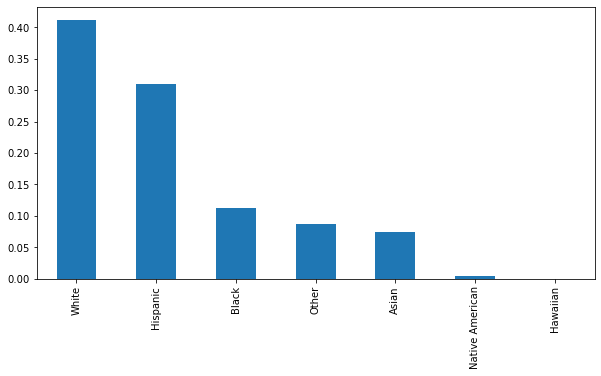

```python
dist.plot(kind='bar', figsize=(10, 5));
```

That's a bit more helpful.

## Aside: Working with time series data

### Time series – why now?

- Data is often partitioned by time. For instance, there may be one `.csv` file per day for 1 year.
- To combine the datasets, we will need to load in the files as DataFrames and `pd.concat` the DataFrames together.
- Note: "time series" is a general term and is not related to Series in `pandas`.

### Datetime types

When working with time data, you will see two different kinds of "times":

- **Datetimes** reference particular moments in time (e.g. November 26th, 1998 at 8:26AM).
  - Could just be a date, e.g. September 15, 2014.
  - Could just be a time, e.g. 4:45 AM.
  - Datetimes typically don't keep track of timezones.
- **Timedeltas**, or durations, reference an exact length of time (e.g. a duration of 3 hours).

### The `datetime` module

Python has an in-built `datetime` module, which contains `datetime` and `timedelta` types. These are much more convenient to deal with than strings that contain times.

```python
import datetime
```

```python
datetime.datetime.now()
```

```
datetime.datetime(2022, 4, 15, 13, 3, 11, 143648)
```

```python
datetime.datetime.now() + datetime.timedelta(days=3, hours=5)
```

```
datetime.datetime(2022, 4, 18, 18, 3, 11, 147079)
```

Recall, Unix timestamps count the number of seconds since January 1st, 1970.

```python
datetime.datetime.now().timestamp()
```

```
1650052991.150548
```

### Times in `pandas`

- `pd.Timestamp` is the `pandas` equivalent of `datetime`.
- `pd.to_datetime` converts strings to `pd.Timestamp` objects.

```python
pd.Timestamp(year=1998, month=11, day=26)
```

```
Timestamp('1998-11-26 00:00:00')
```

```python
final_start = pd.to_datetime('June 4th, 2022, 11:30AM')
final_start
```

```
Timestamp('2022-06-04 11:30:00')
```

```python
final_finish = pd.to_datetime('June 4th, 2022, 2:30PM')
final_finish
```

```
Timestamp('2022-06-04 14:30:00')
```

Timestamps have time-related attributes, e.g. `dayofweek`, `hour`, `min`, `sec`.

```python
final_finish.dayofweek
```

```
5
```

```python
final_finish.year
```

```
2022
```

Subtracting timestamps yields `pd.Timedelta` objects.

```python
final_finish - final_start
```

```
Timedelta('0 days 03:00:00')
```

### Timestamps in DataFrames

- If we create a Series of datetimes with `pd.to_datetime`, `pandas` stores them as yet *another* type: `np.datetime64`.
  - These are similar to `pd.Timestamp`, but optimized for memory and speed efficiency.
- If we access a single time, we get a `pd.Timestamp` back.
- See [the documentation](https://pandas.pydata.org/pandas-docs/stable/user_guide/timeseries.html) for more details.

```python
times = pd.DataFrame({'finish': pd.to_datetime(['Sun, Jan 01, 1989',
                                                '2022-04-15T11:00',
                                                '1/1/1970'])})
times
```

|  | finish |
| --- | --- |
| 0 | 1989-01-01 00:00:00 |
| 1 | 2022-04-15 11:00:00 |
| 2 | 1970-01-01 00:00:00 |

```python
times.info()
```

```
<class 'pandas.core.frame.DataFrame'>
RangeIndex: 3 entries, 0 to 2
Data columns (total 1 columns):
 #   Column  Non-Null Count  Dtype
---  ------  --------------  -----
 0   finish  3 non-null      datetime64[ns]
dtypes: datetime64[ns](1)
memory usage: 152.0 bytes
```

```python
times.iloc[0, 0]
```

```
Timestamp('1989-01-01 00:00:00')
```

```python
times.sort_values('finish')
```

|  | finish |
| --- | --- |
| 2 | 1970-01-01 00:00:00 |
| 0 | 1989-01-01 00:00:00 |
| 1 | 2022-04-15 11:00:00 |

### Example: Exam speeds

Below, we have the Final Exam starting and ending times for two sections of a course.

```python
times_A = pd.DataFrame({
    'Name': ['Annie', 'Billy', 'Sally', 'Tommy'],
    'start_exam': ['15:00', '15:02', '15:01', '15:00'],
    'finish_exam': ['16:00', '17:58', '17:05', '16:55']
})

times_B = pd.DataFrame({
    'Name': ['Junior', 'Rex', 'Flash'],
    'start_exam': ['18:00', '18:06', '19:07'],
    'finish_exam': ['20:00', '20:50', '20:59']
})

display(times_A)
display(times_B)
```

|  | Name | start_exam | finish_exam |
| --- | --- | --- | --- |
| 0 | Annie | 15:00 | 16:00 |
| 1 | Billy | 15:02 | 17:58 |
| 2 | Sally | 15:01 | 17:05 |
| 3 | Tommy | 15:00 | 16:55 |

|  | Name | start_exam | finish_exam |
| --- | --- | --- | --- |
| 0 | Junior | 18:00 | 20:00 |
| 1 | Rex | 18:06 | 20:50 |
| 2 | Flash | 19:07 | 20:59 |

**Question:** Who finished the exam the fastest amongst all students in the course?

Approach:

1. Concatenate the two DataFrames.
2. Convert the time columns to `pd.Timestamp`.
3. Find the difference between `'finish_exam'` and `'start_exam'`.
4. Sort.
5. Pick the fastest exam taker.

```python
# Step 1
both_versions = pd.concat([times_A, times_B])
both_versions
```

|  | Name | start_exam | finish_exam |
| --- | --- | --- | --- |
| 0 | Annie | 15:00 | 16:00 |
| 1 | Billy | 15:02 | 17:58 |
| 2 | Sally | 15:01 | 17:05 |
| 3 | Tommy | 15:00 | 16:55 |
| 0 | Junior | 18:00 | 20:00 |
| 1 | Rex | 18:06 | 20:50 |
| 2 | Flash | 19:07 | 20:59 |

```python
# Step 2
both_versions = both_versions.assign(
    start_exam=pd.to_datetime(both_versions['start_exam']),
    finish_exam=pd.to_datetime(both_versions['finish_exam'])
)

both_versions.info()
```

```
<class 'pandas.core.frame.DataFrame'>
Int64Index: 7 entries, 0 to 2
Data columns (total 3 columns):
 #   Column       Non-Null Count  Dtype
---  ------       --------------  -----
 0   Name         7 non-null      object
 1   start_exam   7 non-null      datetime64[ns]
 2   finish_exam  7 non-null      datetime64[ns]
dtypes: datetime64[ns](2), object(1)
memory usage: 224.0+ bytes
```

```python
# Step 3
both_versions = both_versions.assign(
    elapsed=both_versions['finish_exam'] - both_versions['start_exam']
)

both_versions
```

|  | Name | start_exam | finish_exam | elapsed |
| --- | --- | --- | --- | --- |
| 0 | Annie | 2022-04-15 15:00:00 | 2022-04-15 16:00:00 | 0 days 01:00:00 |
| 1 | Billy | 2022-04-15 15:02:00 | 2022-04-15 17:58:00 | 0 days 02:56:00 |
| 2 | Sally | 2022-04-15 15:01:00 | 2022-04-15 17:05:00 | 0 days 02:04:00 |
| 3 | Tommy | 2022-04-15 15:00:00 | 2022-04-15 16:55:00 | 0 days 01:55:00 |
| 0 | Junior | 2022-04-15 18:00:00 | 2022-04-15 20:00:00 | 0 days 02:00:00 |
| 1 | Rex | 2022-04-15 18:06:00 | 2022-04-15 20:50:00 | 0 days 02:44:00 |
| 2 | Flash | 2022-04-15 19:07:00 | 2022-04-15 20:59:00 | 0 days 01:52:00 |

```python
# Steps 4 and 5
both_versions.sort_values('elapsed').iloc[0].loc['Name']
```

```
'Annie'
```

## Summary, next time

### Summary

- `pd.concat` "stitches" two or more DataFrames together, either vertically or horizontally.
  - Vertically: looks at column names. Horizontally: looks at row indexes.
- The `merge` DataFrame method **joins** two DataFrames together based on a shared column, called a join key. There are four types of joins:
  - Inner join: keeps the **intersection** of the join keys.
  - Outer join: keeps the **union** of the join keys.
  - Left/right joins: keeps all of the join keys in the left/right DataFrame.
  - In outer/left/right joins, all missing fields are filled with `NaN`s.
- Timestamps in `pandas` are stored using `pd.Timestamp` and `pd.Timedelta` objects.
- **Next time:** Permutation testing!